# visStatistics: The right test, visualised.

The R package `visStatistics` allows for rapid **vis**ualisation and statistical analysis of raw data. It automatically selects and visualises the most appropriate **statistic**al hypothesis test between a response (`varsample`) and a predictor (`varfactor`) within a `data.frame`.

Both `varsample` and `varfactor` must be character strings corresponding to column names of the response and feature variables, respectively.

This workflow is particularly suited for browser-based interfaces that rely on server-side R applications connected to secure databases, where users have no direct access, or for quick data visualisation, e.g. in statistical consulting projects.

# Getting Started

A minimal function call of the main function `visstat()` looks like:

```r
visstat(dataframe, varsample = "response", varfactor = "feature")
```

The function selects a statistical test based on the class of the corresponding response and predictor variables, the number of levels in categorical variables, and conditions such as normality and homoscedasticity.

The automatically generated output figures illustrate the selected statistical test, display the main test statistics, and include assumption checks and post hoc comparisons when applicable. The primary test results are returned as a list object.

# Installation of latest stable version from CRAN

1. Install the package

```r
install.packages("visStatistics")
```

2. Load the package

```r
library(visStatistics)
```

# Installation of the development version from GitHub

1. Install **devtools** from CRAN if not already installed:

```r
install.packages("devtools")
```

2. Load the **devtools** package:

```r
library(devtools)
```

3. Install the `visStatistics` package from GitHub:

```r
install_github("shhschilling/visStatistics")
```

4. Load the `visStatistics` package:

```r
library(visStatistics)
```

5. View help for the main function:

```r
? visstat
```

# Decision logic

Throughout the remainder, data of class `"numeric"` or `"integer"` are referred as numeric, while data of class `"factor"` are referred to as categorical.

The choice of statistical tests depends on whether the data of the selected columns are numeric or categorical, the number of levels in the categorical variable, and the distribution of the data. The function prioritizes interpretable visual output and tests that remain valid under the the following decision logic:

## Numerical response and categorical predictor

When the response is numeric and the predictor is categorical, a statistical hypothesis test of central tendencies is selected.

- If the categorical predictor has exactly two levels, Welch’s t - test (`t.test()`), is applied whenever both groups contain more than 30 observations, with the validity of the test supported by the approximate normality of the sampling distribution of the mean under the central limit theorem [@Rasch:2011vl @Lumley2002dsa]. For smaller samples, group - wise normality is assessed using the Shapiro - Wilk test (`shapiro.test()`) at the significance level$\alpha$. If both groups are found to be approximately normally distributed according to the Shapiro - Wilk test, Welch’s t-test is applied; otherwise, the Wilcoxon rank-sum test (`wilcox.test()`) is used.
- For predictors with more than two levels, an ANOVA model (`aov()`) is initially fitted. The normality of residuals is evaluated using both the Shapiro–Wilk test (`shapiro.test()`) and the Anderson–Darling test (`ad.test()`); residuals are considered approximately normal if at least one of the two tests yields a result exceeding the significance threshold $\alpha$. If this condition is met, Bartlett’s test (`bartlett.test()`) is then used to assess homoscedasticity. When variances are homogeneous ($p > \alpha$), ANOVA is applied with Tukey’s HSD (`TukeyHSD()`) for post-hoc comparison. If variances differ significantly ($p \le \alpha$), Welch’s one - way test (`oneway.test()`) is used, also followed by Tukey’s HSD. If residuals are not normally distributed according to both tests ($p \le \alpha$), the Kruskal-Wallis test (`kruskal.test()`) is selected, followed by pairwise Wilcoxon tests (`pairwise.wilcox.test()`). A graphical overview of the decision logic used is provided in below figure.

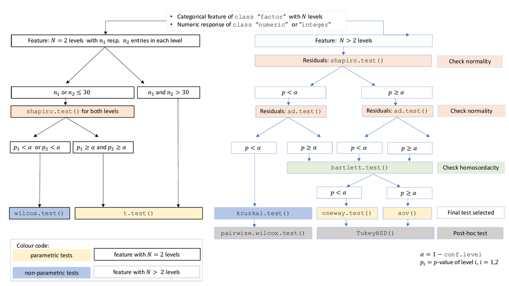

Decision tree used to select the appropriate statistical test for a categorical predictor and numeric response, based on the number of factor levels, normality, and homoscedasticity.

## Numerical response and numerical predictor: Linear Regression

When both the response and predictor are numeric, a simple linear regression model (`lm()`) is fitted and analysed in detail, including residual diagnostics, formal tests, and the plotting of fitted values with confidence bands. Note that only one explanatory variable is allowed, as the function is designed for two-dimensional visualisation.

For a more detailed description of the underlying decision logic see

```r
vignette("visStatistics")
```

# Limitations

The main purpose of this package is a decision-logic based automatic visualisation of statistical test results. Therefore, except for the user-adjustable `conf.level` parameter, all statistical tests are applied using their default settings from the corresponding base R functions. As a consequence, paired tests are currently not supported and `visstat()` does not allow to study interactions terms between the different levels of an independent variable in an analysis of variance. Focusing on the graphical representation of tests, only simple linear regression is implemented, as multiple linear regressions cannot be visualised.

# Examples

```r
library(visStatistics)
```

## Standardised usage with vectors

```r
# Numeric response, categorical predictor (t-test or Wilcoxon)
visstat(grades_gender$sex, grades_gender$grade)

# Numeric response, multi-level factor (ANOVA or nonparametric)
visstat(npk$block, npk$yield)

# Both numeric (linear regression)
visstat(trees$Girth, trees$Height)

# Both factors (Chi-squared or Fisher's test)
hair_eye <- counts_to_cases(as.data.frame(HairEyeColor))
visstat(hair_eye$Hair, hair_eye$Eye)
```

## Example showing both forms

```r
# These are equivalent
visstat(iris$Species, iris$Petal.Width)
visstat(iris, "Species", "Petal.Width")
```

## Saving output

```r
visstat(
  iris$Species,
  iris$Petal.Width,
  graphicsoutput = "pdf",
  plotDirectory = tempdir()
)
```

# Implemented tests

### Numerical response and categorical predictor

#### Main tests

`t.test()`, `wilcox.test()`, `aov()`, `oneway.test()`, `kruskal.test()`

#### Normality assumption check

`shapiro.test()` and `ad.test()`

#### Homoscedasticity assumption check

`bartlett.test()`

- `pairwise.wilcox.test()` (used following `kruskal.test()`)

### Numerical response and numerical predictor

When both the response and predictor are numerical, a simple linear regression model is fitted:`lm()`

When both variables are categorical, `visstat()` tests the null hypothesis of independence using one of the following:-`chisq.test()` (default for larger samples) - `fisher.test()` (used for small expected cell counts based on Cochran’s rule)